# Final Project - Oliver Zhao - soz63

First we load the relevant libraries and datasets for this project:

```r
# Import libraries
library(randomForest)
library(ggplot2)
library(mosaic)
library(tidyverse)
library(caret)
library(ltm)
library(matrixStats)

# Import NCB dataset
Data <- read.csv("~/Github/SDS323_Spring2020/NCBFeatures.csv")

# Set random seed for entire markdown document
set.seed(123)
```

# Abstract

NanoCluster Beacons (NCBs) are an emerging class of fluorescent activatable molecular probes with the ability to detect proteins, metabolites, and cancer cells. The fluorescent response of the NCBs can be fine-tuned by altering the DNA sequence of the associated activator strand, allowing NCBs to be customized as versatile probes. However, with the DNA activator strand consisting of 18 nucleotides, even modern high-throughput methods that are able to screen ~12,000 sequences at once are not able to fully characterize the possible variants of NCBs.

While developing the appropriate DNA sequence to target specific molecules remains a challenging task, another relevant issue is ensuring that the NCBs are sufficiently bright in order to act as effective fluorescent markers. To address this challenge, we create a random forest model that predicts whether a NCB is bright enough based on its DNA sequence, achieving an accuracy of $95.58\%$, sensitivity of $95.92\%$, and specificity of $95.23\%$. The features are extracted through a third-party software package, in which we implement correlation based feature selection and implicit feature selection to isolate relevant features for our final model. The model accelerates the development of new NCBs by identifying whether the proposed DNA sequence satisfies the desired fluorescent intensity.

# Introduction

Silver NanoCluster Beacons (Ag NCBs) are DNA-templated molecules consisting of several silver atoms, serving as cheap and customizable molecular markers. Under normal conditions, NCBs are dark and elicit no fluorescent signal. Upon binding to an appropriate molecular target, the conformation of the DNA-templated NCB changes to emit strong fluorescent signals (Figure 1). The NCB DNA sequence can be customized to bind to different targets, such as specific proteins or molecules. In addition to the NCB DNA sequence, there is a seperate activator DNA sequence. The activator DNA sequence does not affect what type of molecules the NCB binds to, but rather, it controls how bright the NCBs are when bound to the target molecule. The design rules of the activator DNA sequence are unclear, reducing the development of the activator DNA sequence to laborious and often frustrating trial-and-error. Recent high-throughput methods that can screen up to approximately 12,000 unique activator DNA sequences help mitigate this challenge, but is exceedingly expensive and requires significant materials such as advanced microscopy imaging systems and customized molecular assays. In addition, with the activator DNA sequence being 18 nucleotides long, the ability to screen 12,000 unique activator DNA sequences is still a small fraction of the possible $4^{18}$ activator sequences. To bridge this gap, we develop a machine learning model that can predict the brightness of the NCBs based on the activator DNA sequence, with the training and testing data derived from these expensive, high-throughput experiments.

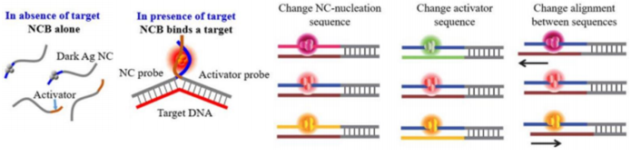

**Figure 1.** Schematic of Ag NCB.

# Methods

## Dataset

The Chip-Hybridized Associationg Mapping Platform (CHAMP) allows for the screening of 12,288 distinct DNA activator sequences, each with roughly 100-200 duplicate clonal DNA clusters. The resulting data consists of activator DNA sequences ranked in descending order of fluorescent brightness. To avoid the ambiguity of “bright” and “dark” DNA activator sequences, we classify “bright” sequences as DNA activator sequences belonging to the top 30% ranked sequences and “dark” sequences as DNA activator sequences belonging to the bottom 30% ranked sequences, with the middle 40% of sequences discarded. The feature extracted dataset is provided as “NCBFeatures.csv”. The data is collected from the NanoBiosensors and Molecular Tracking Lab at UT Austin.

## Feature Extraction

With the raw dataset containing only a list of activator DNA sequences in rank order of brightness, different DNA features must still be extracted. The DNA features are extracted using a third-party Python software package - PyFeat - which is available at https://github.com/mrzResearchArena/PyFeat/. Through this software, we extract 16,171 different DNA features (Figure 2), stored in the dataset we use (“NCBFeatures.csv”). Most features consist of different DNA motifs, where **N** indicates a variable nucleotide and **_** indicates a gap of 0 to 5 nucleotides. For example, the feature **A_T** may represent **ATT**, **AT**, or **AGCGCT**. For each of these motif features, the value indicates the number of occurences of each motif. Other features include basic holistic characterizations of the activator DNA sequence, such as the % of bases that are G or C (GC content) or the AT-GC ratio.

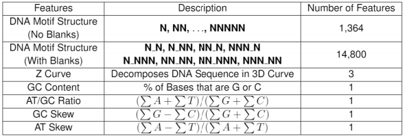

**Figure 2.** Table of extracted features.

## Feature Selection

Features that contain the same value across all data points were removed. Then the point-biserial correlation coefficient for each feature, relative to the DNA activator sequences brightness class, was calculated. Features with a correlation coefficient between -0.05 to 0.05 were excluded due to the likelihood of having lower discriminatory power. Finally, a random forest model with 50 trees was trained on the full dataset with the remaining features that were not removed due to low discriminatory power. Afterwards, the importance of each feature was calculated for each of these features. All other hyperparameters were default settings. Due to the high dimensionality of the dataset, overfitting is a possibility. To address this issue, features were excluded based on a feature importance threshold, ranging from 0.10 to 15. Then, these feature sets were used to train random forest models with 50 trees each with 10-fold cross validation to determine which number of features is optimal.

## Model Hyperparameter Tuning

Once the optimal number of features - based on an feature importance threshold - was determined, we implement a traditional grid search of the hyperparameters `mtry` and `maxnodes`, which control the number of variables tested at each node and the maximum number of terminal nodes, respectively. These two hyperparameters are the most likely to affect the performance of the model, so only these two hyperparameters were tuned to avoid having to test too many model variants. Once the ideal `mtry` and `maxnodes` is determined, we expand the number of trees from 50 to 500, as a higher number of trees elicits better performance up to a certain point. Previously, the number of trees were limited to 50 to avoid heavy computational burden. A random forest model was selected because it is easily scalable with increasing number of trees, can be trained in parallel (opposed to boosting methods) to reduce computational burden, and requires minimal feature selection and feature scaling.

# Results

## Feature Selection

[figure not shown]

**Figure 3.** Feature selection process.

```r
# Preprocess dataset
Data$X1 <- as.factor(Data$X1)  # factorize class
n <- nrow(Data)                # number of data points
f <- ncol(Data)-1              # number of features

# Correlation Feature Selection: Remove Low Point-Biserial Correlations
Cor <- vector("double", f)
CorData <- Data
for (i in f:1){
  Cor[i] <- biserial.cor(CorData[,c(i)],CorData$X1)
  if (is.na(Cor[i])){
    CorData <- CorData[,-c(i)]
  }
  else{
    if (abs(Cor[i]) < 0.05){
      CorData <- CorData[,-c(i)]
    }}
}

# Implicit Feature Selection: Train Random Forest on Reduced Dataset
rf <- randomForest(X1 ~ .,
                   data= CorData,
                   ntree = 50)
Features <- importance(rf)

# Model Complexity Analysis for Overfitting and Underfitting
CV <- 10
Folds <- seq(0,n,length.out = CV+1)
Importances <- c(0.10,0.20,0.30,0.50,1,2,8,15)
FeatureCount <- c(0,0,0,0,0,0,0,0)
TreeAcc <- matrix(0, nrow = CV, ncol = length(Importances))
TreeSen <- matrix(0, nrow = CV, ncol = length(Importances))
TreeSpe <- matrix(0, nrow = CV, ncol = length(Importances))
TreePpv <- matrix(0, nrow = CV, ncol = length(Importances))
TreeNpv <- matrix(0, nrow = CV, ncol = length(Importances))

for (j in 1:length(Importances)){

  # Isolate subset with most important features
  s = ncol(CorData)-1
  RFSelected <- CorData
  for (i in s:1){
    if (Features[i] < Importances[j]){
      RFSelected <- RFSelected[,-c(i)]
    }
  }
  FeatureCount[j] <- ncol(RFSelected)

  # Shuffle rows
  rows <- sample(nrow(RFSelected))
  RFSelected <- RFSelected[rows,]

  for (i in 1:CV){

    # Split train and test sets by CV fold
    train <- RFSelected[ c(Folds[i]:Folds[i+1]),]
    test  <- RFSelected[-c(Folds[i]:Folds[i+1]),]

    # Train random forest
    rf <- randomForest(X1 ~ .,
                       data=train,
                       ntree = 50)

    # Predict on test set
    pred <- predict(rf, newdata=test)

    # Create confusion matrix
    results <- confusionMatrix(pred,test$X1)

    TreeAcc[i,j] <- results[3]$overall[1]
    TreeSen[i,j] <- results[4]$byClass[1]
    TreeSpe[i,j] <- results[4]$byClass[2]
    TreePpv[i,j] <- results[4]$byClass[3]
    TreeNpv[i,j] <- results[4]$byClass[4]
  }
}
```

[figure not shown]

**Figure 4.** Model performance based on number of features used.

```r
FeatureResults <- data.frame(Importances)
FeatureResults$NumFea <- FeatureCount
FeatureResults$AccAvg <- colMeans(TreeAcc)
FeatureResults$SenAvg <- colSds(TreeSen)
FeatureResults$SpeAvg <- colSds(TreeSpe)
FeatureResults$PpvAvg <- colSds(TreePpv)
FeatureResults$NpvAvg <- colSds(TreeNpv)
FeatureResults$AccStd <- colSds(TreeAcc)
FeatureResults$SenStd <- colSds(TreeSen)
FeatureResults$SpeStd <- colSds(TreeSpe)
FeatureResults$PpvStd <- colSds(TreePpv)
FeatureResults$NpvStd <- colSds(TreeNpv)

FeatureResults
  Importances NumFea    AccAvg      SenAvg      SpeAvg      PpvAvg      NpvAvg
1         0.1   1724 0.9517801 0.003657793 0.011487255 0.010887959 0.003478059
2         0.2   1189 0.9545091 0.005485160 0.007721144 0.007160218 0.005243294
3         0.3    917 0.9556400 0.006980529 0.008247492 0.007696207 0.006528123
4         0.5    612 0.9538306 0.006426226 0.010294542 0.009284211 0.005987465
5         1.0    359 0.9540568 0.004913555 0.006830378 0.006417354 0.004842003
6         2.0    217 0.9517197 0.007791513 0.008236453 0.007627268 0.007267614
7         8.0     94 0.9520665 0.007924248 0.010414824 0.009800177 0.007461952
8        15.0     60 0.9436528 0.005090599 0.008327051 0.007430456 0.004680291
       AccStd      SenStd      SpeStd      PpvStd      NpvStd
1 0.005066056 0.003657793 0.011487255 0.010887959 0.003478059
2 0.003047564 0.005485160 0.007721144 0.007160218 0.005243294
3 0.002816931 0.006980529 0.008247492 0.007696207 0.006528123
4 0.003760995 0.006426226 0.010294542 0.009284211 0.005987465
5 0.003092436 0.004913555 0.006830378 0.006417354 0.004842003
6 0.004218995 0.007791513 0.008236453 0.007627268 0.007267614
7 0.003041975 0.007924248 0.010414824 0.009800177 0.007461952
8 0.002092047 0.005090599 0.008327051 0.007430456 0.004680291
```

## Hyperparameter-Tuning of Classifier Model

The best performing random forest model had `mtry = 50` and `maxnodes = 99999`, with the latter indicating that there is essentially not limit on the maximum number of nodes. The top performing model has an accuracy of $95.51 \pm 0.29 \%$, sensitivity of $95.76 \pm 0.43 \%$, specificity of $95.27 \pm 0.82 \%$, positive predictivity of $95.31 \pm 0.78 \%$, and negative predictivity of $95.74 \pm 40 \%$.

```r
# Isolate subset with most important features
s = ncol(CorData)-1
RFSelected <- CorData
for (i in s:1){
  if (Features[i] < 0.3){
    RFSelected <- RFSelected[,-c(i)]
  }
}

# Shuffle rows
rows <- sample(nrow(RFSelected))
RFSelected <- RFSelected[rows,]

# Model Hyperparameter Tuning
CV <- 10
Folds <- seq(0,nrow(RFSelected),length.out = CV+1)
Tries <- c(10,30,50)
Nodes <- c(25,100,99999)

# Create dataframe to store results
Model <- data.frame(mtry = rep(Tries, each = length(Nodes)),
                    maxnodes = c(Nodes,Nodes,Nodes),
                    AccAvg = NA, AccStd = NA,
                    SenAvg = NA, SenStd = NA,
                    SpeAvg = NA, SpeStd = NA,
                    PpvAvg = NA, PpvStd = NA,
                    NpvAvg = NA, NpvStd = NA)

for (k in 1:length(Tries)){

  for (j in 1:length(Nodes)){

    TreeAcc = rep(0,CV)
    TreeSen = rep(0,CV)
    TreeSpe = rep(0,CV)
    TreePpv = rep(0,CV)
    TreeNpv = rep(0,CV)

    for (i in 1:CV){

      # Split train and test sets by CV fold
      train <- RFSelected[ c(Folds[i]:Folds[i+1]),]
      test  <- RFSelected[-c(Folds[i]:Folds[i+1]),]

      # Train random forest
      rf <- randomForest(X1 ~ .,
                         data=train,
                         ntree = 50,
                         mtry = Tries[k],
                         maxnodes = Nodes[j])

      # Predict on test set
      pred <- predict(rf, newdata=test)

      # Create confusion matrix
      results <- confusionMatrix(pred,test$X1)
      TreeAcc[i] <- results[3]$overall[1]
      TreeSen[i] <- results[4]$byClass[1]
      TreeSpe[i] <- results[4]$byClass[2]
      TreePpv[i] <- results[4]$byClass[3]
      TreeNpv[i] <- results[4]$byClass[4]
    }

    # Store CV results
    n <- (k-1)*3+j

    Model$AccAvg[n] <- mean(TreeAcc)
    Model$SenAvg[n] <- mean(TreeSen)
    Model$SpeAvg[n] <- mean(TreeSpe)
    Model$PpvAvg[n] <- mean(TreePpv)
    Model$NpvAvg[n] <- mean(TreeNpv)

    Model$AccStd[n] <- sd(TreeAcc)
    Model$SenStd[n] <- sd(TreeSen)
    Model$SpeStd[n] <- sd(TreeSpe)
    Model$PpvStd[n] <- sd(TreePpv)
    Model$NpvStd[n] <- sd(TreeNpv)
  }
}

# Display GridCV results
Model
  mtry maxnodes    AccAvg      AccStd    SenAvg      SenStd    SpeAvg
1   10       25 0.9324650 0.005878636 0.9657867 0.002574879 0.8991453
2   10      100 0.9523228 0.004216537 0.9612968 0.003802405 0.9433644
3   10    99999 0.9523831 0.004073920 0.9610842 0.004352800 0.9436936
4   30       25 0.9420245 0.004716026 0.9636140 0.003939368 0.9204256
5   30      100 0.9549464 0.004552756 0.9590684 0.004650493 0.9508499
6   30    99999 0.9541774 0.003924201 0.9587330 0.003998609 0.9496402
7   50       25 0.9478748 0.003737295 0.9618960 0.004290717 0.9338510
8   50      100 0.9550369 0.003447429 0.9581320 0.005052605 0.9519610
9   50    99999 0.9551424 0.002911609 0.9575586 0.004327614 0.9527420
       SpeStd    PpvAvg      PpvStd    NpvAvg      NpvStd
1 0.012387582 0.9055903 0.010739780 0.9633287 0.002561436
2 0.008803241 0.9444398 0.008375460 0.9605761 0.003720074
3 0.007431287 0.9447143 0.007128005 0.9603833 0.004286037
4 0.011632284 0.9238832 0.010092413 0.9619839 0.003679659
5 0.009282435 0.9513272 0.008949922 0.9587170 0.004493770
6 0.008917969 0.9501743 0.008553697 0.9583478 0.003780152
7 0.009331613 0.9357710 0.008339329 0.9608053 0.004070516
8 0.008064533 0.9523296 0.007747514 0.9578740 0.004781878
9 0.008165163 0.9530529 0.007794314 0.9573530 0.004007285
```

## Final Model Performance

```r
# Model Hyperparameter Tuning
CV <- 10
Folds <- seq(0,nrow(RFSelected),length.out = CV+1)

# Initalize memory to story metrics
TreeAcc <- matrix(0, nrow = CV, ncol = 1)
TreeSen <- matrix(0, nrow = CV, ncol = 1)
TreeSpe <- matrix(0, nrow = CV, ncol = 1)
TreePpv <- matrix(0, nrow = CV, ncol = 1)
TreeNpv <- matrix(0, nrow = CV, ncol = 1)

for (i in 1:CV){

  # Split train and test sets by CV fold
  train <- RFSelected[ c(Folds[i]:Folds[i+1]),]
  test  <- RFSelected[-c(Folds[i]:Folds[i+1]),]

  # Train random forest
  rf <- randomForest(X1 ~ .,
                     data=train,
                     ntree = 500,
                     mtry = 30)

  # Predict on test set
  pred <- predict(rf, newdata=test)

  # Create confusion matrix
  results <- confusionMatrix(pred,test$X1)
  TreeAcc[i,1] <- results[3]$overall[1]
  TreeSen[i,1] <- results[4]$byClass[1]
  TreeSpe[i,1] <- results[4]$byClass[2]
  TreePpv[i,1] <- results[4]$byClass[3]
  TreeNpv[i,1] <- results[4]$byClass[4]
}

mean(TreeAcc)
[1] 0.9557606
mean(TreeSen)
[1] 0.9592185
mean(TreeSpe)
[1] 0.9523265
mean(TreePpv)
[1] 0.9527537
mean(TreeNpv)
[1] 0.958949
sd(TreeAcc)
[1] 0.003400278
sd(TreeSen)
[1] 0.005241484
sd(TreeSpe)
[1] 0.009506616
sd(TreePpv)
[1] 0.009079455
sd(TreeNpv)
[1] 0.004892455
```

# Conclusions

As such, we have developed a model that effectively allows us to design our NCB molecular sensors *in silico*, opposed to the traditional method of generating several expensive sequences, running tedious experiments, and essentially crossing our fingers hoping that the NCB turns out the way we want it to.